# Prediction Assignment Writeup

Dustin B

April 3, 2016

## Summary

The “classe” variable in the dataset refers to the quality of exercise. This study seeks to develop a model to predict that variable based on the measurement variables in the dataset.

## Loading Data and Packages

```r
library(caret)
library(randomForest)
```

```r
library(rpart)
library(rpart.plot)
library(ggplot2)
```

data can be directly downloaded from link:

```r
traindata <- read.csv("https://d396qusza40orc.cloudfront.net/predmachlearn/pml-training.csv", na.strings=c("NA","#DIV/0!",""))
testdata <- read.csv("https://d396qusza40orc.cloudfront.net/predmachlearn/pml-testing.csv", na.strings=c("NA","#DIV/0!",""))
```

The seed is set in order to make the results reproducible. The value itself does not matter.

```r
set.seed(1979)
```

## Cleaning Data

The dataset has a huge number of variables, most of which are likely not relevant to determining the “classe”. First we can remove the first seven variables which contain index numbers, names of participants, and time windows. These could potentially skew our results if not removed since some are numeric.

```r
traindata <- traindata[, -(1:7)]
testdata  <- testdata[, -(1:7)]
```

Many of the columns have a very high number of NA values. We will remove all columns where a majority of the observed values are NA.

```r
naframe <- as.vector(colMeans(is.na(traindata)))
namost <- naframe > .60
traindata <- traindata[,!namost]
testdata <- testdata[,!namost]
```

In this case all of the columns that have any NAs have more than 90% NAs, but the operation here is set for a 60% threshold. The testdata must be altered in the same way that the training data is so that we can apply our models later.

## Build Training Data

Though we have a training set and a test set, we want to split part of the training data into a testing set so that we can cross-validate and evaluate our models for use on the test data.

```r
inTrain <- createDataPartition(y=traindata$classe,p=.70,list=FALSE)
trainingset <- traindata[inTrain,]
validationset <- traindata[-inTrain,]
```

## Models

First we will try a tree model to see if that is a sufficient prediction method.

```r
treemodel <- rpart(classe ~ ., data=trainingset, method="class")
```

We can plot the tree to show the complexity.

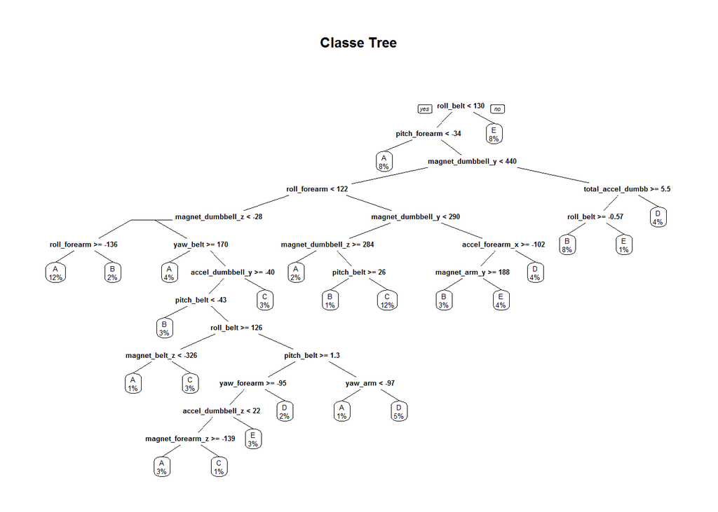

```r
rpart.plot(treemodel, main="Classe Tree",extra=100)
```

The high number of branches makes the tree difficult to interpret. We can test this model on our validation data subset:

```r
treeprediction <- predict(treemodel, validationset, type = "class")
confusionMatrix(treeprediction, validationset$classe)
```

```
## Confusion Matrix and Statistics
##
##           Reference
## Prediction    A    B    C    D    E
##          A 1529  186   18   57   28
##          B   66  663  101   84   90
##          C   36   99  815  141  114
##          D   19   89   61  608   56
##          E   24  102   31   74  794
##
## Overall Statistics
##
##                Accuracy : 0.7492
##                  95% CI : (0.7379, 0.7602)
##     No Information Rate : 0.2845
##     P-Value [Acc > NIR] : < 2.2e-16
##
##                   Kappa : 0.6818
##  Mcnemar's Test P-Value : < 2.2e-16
##
## Statistics by Class:
##
##                      Class: A Class: B Class: C Class: D Class: E
## Sensitivity            0.9134   0.5821   0.7943   0.6307   0.7338
## Specificity            0.9314   0.9282   0.9197   0.9543   0.9519
## Pos Pred Value         0.8410   0.6604   0.6763   0.7299   0.7746
## Neg Pred Value         0.9643   0.9025   0.9549   0.9295   0.9407
## Prevalence             0.2845   0.1935   0.1743   0.1638   0.1839
## Detection Rate         0.2598   0.1127   0.1385   0.1033   0.1349
## Detection Prevalence   0.3089   0.1706   0.2048   0.1415   0.1742
## Balanced Accuracy      0.9224   0.7551   0.8570   0.7925   0.8429
```

```r
rfmodel <- train(classe ~. , data=trainingset, method="rf",ntree=100)
rfprediction <- predict(rfmodel, validationset, type = "raw")
confusionMatrix(rfprediction, validationset$classe)
```

```
## Confusion Matrix and Statistics
##
##           Reference
## Prediction    A    B    C    D    E
##          A 1672   18    0    0    0
##          B    1 1116    5    0    0
##          C    0    5 1018   12    3
##          D    0    0    3  952    2
##          E    1    0    0    0 1077
##
## Overall Statistics
##
##                Accuracy : 0.9915
##                  95% CI : (0.9888, 0.9937)
##     No Information Rate : 0.2845
##     P-Value [Acc > NIR] : < 2.2e-16
##
##                   Kappa : 0.9893
##  Mcnemar's Test P-Value : NA
##
## Statistics by Class:
##
##                      Class: A Class: B Class: C Class: D Class: E
## Sensitivity            0.9988   0.9798   0.9922   0.9876   0.9954
## Specificity            0.9957   0.9987   0.9959   0.9990   0.9998
## Pos Pred Value         0.9893   0.9947   0.9807   0.9948   0.9991
## Neg Pred Value         0.9995   0.9952   0.9983   0.9976   0.9990
## Prevalence             0.2845   0.1935   0.1743   0.1638   0.1839
## Detection Rate         0.2841   0.1896   0.1730   0.1618   0.1830
## Detection Prevalence   0.2872   0.1907   0.1764   0.1626   0.1832
## Balanced Accuracy      0.9973   0.9893   0.9940   0.9933   0.9976
```

```r
testresults <- predict(rfmodel, testdata, type="raw")
```